# AE3

Bruno Sánchez y Oscar Feliz

2025-01-21

```r
#install.packages("ggplot2")
#library(ggplot2)
```

# Obtención y carga de los Datos

### 1. Descomprimir el fichero comprimido que contiene los registros del servidor, y a partir de los datos extraídos, cargar en data frame los registros con las peticiones servidas.

```r
# Definimos  archivo comprimido y  directorio de salida
fichero_comprimido <- "epa-http.zip"
directorio_salida <- "logsEpa"

# Descomprimimos
unzip(fichero_comprimido, exdir = directorio_salida)

# Leemos los registros en un data frame
fichero_log <- file.path(directorio_salida, "epa-http.csv")

# Primero limpiamos las comillas del CSV
texto_sin_comillas <- gsub('"', '', readLines(fichero_log))

# Generamos un fichero temporal para no sobreescribir el fichero original
temp_file <- tempfile()
writeLines(texto_sin_comillas, temp_file)

# Pasamos el archivo temporal en un dataframe
logs_df <- read.table(temp_file, sep = "", header = FALSE, stringsAsFactors = FALSE,fill = TRUE)

# Renombramos columnas
colnames(logs_df) <- c("IP/address","FechaHora","Type", "URL", "Protocolo","Mensaje","Response")

head(logs_df)
```

```
##                IP/address     FechaHora Type                          URL
## 1           141.243.1.172 [29:23:53:25]  GET               /Software.html
## 2 query2.lycos.cs.cmu.edu [29:23:53:36]  GET               /Consumer.html
## 3        tanuki.twics.com [29:23:53:53]  GET                   /News.html
## 4      wpbfl2-45.gate.net [29:23:54:15]  GET                            /
## 5      wpbfl2-45.gate.net [29:23:54:16]  GET /icons/circle_logo_small.gif
## 6      wpbfl2-45.gate.net [29:23:54:18]  GET      /logos/small_gopher.gif
##   Protocolo Mensaje Response
## 1  HTTP/1.0     200     1497
## 2  HTTP/1.0     200     1325
## 3  HTTP/1.0     200     1014
## 4  HTTP/1.0     200     4889
## 5  HTTP/1.0     200     2624
## 6  HTTP/1.0     200      935
```

### 2. Incluid en el documento un apartado con la descripción de los datos analizados: fuente, tipología, descripción de la información contenida (los diferentes campos) y sus valores.

Los datos importados son logs de un servidor Apache sobre peticiones registradas en un servidor. En este fichero de log contiene datos de la dirección de IP o dominio, la hora del registro, el tipo de petición (si es un GET o un POST), la URL a la que se hace la petición, el protocolo de la petición, el resultado (200 u otro diferente) y la respuesta.

# Limpieza de los Datos

### 3. Aprovechando que los datos a analizar son los mismos de la primera práctica, para esta entrega es imprescindible que los datos estén en formato de “datos elegantes”.

```r
# Normalizamos
logs_df$Type <- as.factor(logs_df$Type)
logs_df$Mensaje <- as.factor(logs_df$Mensaje)
logs_df$Response <- as.numeric(logs_df$Response)
logs_df$FechaHora <- as.POSIXct(logs_df$FechaHora, format="[%d:%H:%M:%S]")

head(logs_df)
```

```
##                IP/address           FechaHora Type                          URL
## 1           141.243.1.172 2025-01-29 23:53:25  GET               /Software.html
## 2 query2.lycos.cs.cmu.edu 2025-01-29 23:53:36  GET               /Consumer.html
## 3        tanuki.twics.com 2025-01-29 23:53:53  GET                   /News.html
## 4      wpbfl2-45.gate.net 2025-01-29 23:54:15  GET                            /
## 5      wpbfl2-45.gate.net 2025-01-29 23:54:16  GET /icons/circle_logo_small.gif
## 6      wpbfl2-45.gate.net 2025-01-29 23:54:18  GET      /logos/small_gopher.gif
##   Protocolo Mensaje Response
## 1  HTTP/1.0     200     1497
## 2  HTTP/1.0     200     1325
## 3  HTTP/1.0     200     1014
## 4  HTTP/1.0     200     4889
## 5  HTTP/1.0     200     2624
## 6  HTTP/1.0     200      935
```

# Exploración de Datos

### 4. Identificar el número único de usuarios que han interactuado directamente con el servidor de forma segregada según si los usuarios han tenido algún tipo de error en las distintas peticiones ofrecidas por el servidor.

```r
# Filtramos los registros con errores (códigos 4xx y 5xx)
errores_df <- logs_df[logs_df$Response >= 400 & logs_df$Response < 600, ]

# Filtramos los registros sin errores (códigos 2xx y 3xx)
sin_errores_df <- logs_df[logs_df$Response >= 200 & logs_df$Response < 400, ]

# Contamos el número único de usuarios (IP/address) en cada grupo
num_usuarios_con_errores <- length(unique(errores_df$'IP/address'))
num_usuarios_sin_errores <- length(unique(sin_errores_df$'IP/address'))

# Mostramos los resultados
cat("Número único de usuarios con errores:", num_usuarios_con_errores, "\n")
```

```
## Número único de usuarios con errores: 845
```

```r
cat("Número único de usuarios sin errores:", num_usuarios_sin_errores, "\n")
```

```
## Número único de usuarios sin errores: 1284
```

Hay varios tipos de errores presentes:

- **Error 400 (Bad Request)**: Este error ocurre cuando el servidor no puede entender la solicitud debido a una sintaxis incorrecta o una solicitud malformada.
- **Error 403 (Forbidden)**: Este error indica que el servidor ha entendido la solicitud, pero se niega a autorizarla. Esto suele ocurrir cuando no tienes permisos para acceder al recurso solicitado.
- **Error 404 (Not Found)**: Este error significa que el servidor no puede encontrar el recurso solicitado. Es común cuando la URL está mal escrita o el recurso ha sido eliminado.
- **Error 500 (Internal Server Error)**: Este error genérico indica que el servidor encontró una condición inesperada que le impidió cumplir con la solicitud.
- **Error 501 (Not Implemented)**: Este error significa que el servidor no reconoce el método de solicitud o no tiene la capacidad de soportarlo. Es una indicación de que la funcionalidad requerida no está implementada en el servidor.

# Análisis de Datos

### 5. Analizar los distintos tipos de peticiones HTTP (GET, POST, PUT, DELETE) gestionadas por el servidor, identificando la frecuencia de cada una de estas.

```r
# Contamos la frecuencia de cada tipo de petición HTTP
frecuencia_peticiones <- table(logs_df$Type)

# Convertimos la tabla en un dataframe para facilitar la visualización y mostramos el resultado
frecuencia_peticiones_df <- as.data.frame(frecuencia_peticiones)
colnames(frecuencia_peticiones_df) <- c("Tipo de Peticion", "Frecuencia")
print(frecuencia_peticiones_df)
```

```
##   Tipo de Peticion Frecuencia
## 1              GET      46020
## 2             HEAD        106
## 3             POST       1622
```

### Repetir el análisis, esta vez filtrando previamente aquellas peticiones correspondientes a recursos ofrecidos de tipo imagen.

```r
# Filtramos las peticiones que corresponden a recursos de tipo imagen
logs_imagenes_df <- logs_df[grep("\\.(jpg|jpeg|png|gif|bmp)$", logs_df$URL, ignore.case = TRUE), ]

# Contamos la frecuencia de cada tipo de petición HTTP para los recursos de tipo imagen
frecuencia_peticiones_imagenes <- table(logs_imagenes_df$Type)

# Convertimos la tabla en un dataframe y mostramos el resultado
frecuencia_peticiones_imagenes_df <- as.data.frame(frecuencia_peticiones_imagenes)
colnames(frecuencia_peticiones_imagenes_df) <- c("TipoPeticion", "Frecuencia")
print(frecuencia_peticiones_imagenes_df)
```

```
##   TipoPeticion Frecuencia
## 1          GET      22179
## 2         HEAD         56
## 3         POST        206
```

Además, podemos ver los tipos de imágenes que se han cargado.

```r
# Extraemos las extensiones de los archivos de imagen
logs_imagenes_df$Extension <- tolower(sub(".*\\.(.*)$", "\\1", logs_imagenes_df$URL))

# Contamos la frecuencia de cada tipo de imagen
frecuencia_imagenes <- table(logs_imagenes_df$Extension)

# Convertimos la tabla en un dataframe y mostramos el resultado
frecuencia_imagenes_df <- as.data.frame(frecuencia_imagenes)
colnames(frecuencia_imagenes_df) <- c("TipoImagen", "Frecuencia")
print(frecuencia_imagenes_df)
```

```
##   TipoImagen Frecuencia
## 1        gif      22414
## 2        jpg         27
```

# Visualización de Resultados

### 6. Generar al menos 2 gráficos distintos que permitan visualizar alguna característica relevante de los datos analizados. Estos deberán representar por lo menos 1 o 2 variables diferentes del data frame. Describid el gráfico e indicad cualquier observación destacable que se pueda apreciar gracias a la representación gráfica.

En primer lugar, podemos observar que la mayoría de peticiones han sido de tipo GET.

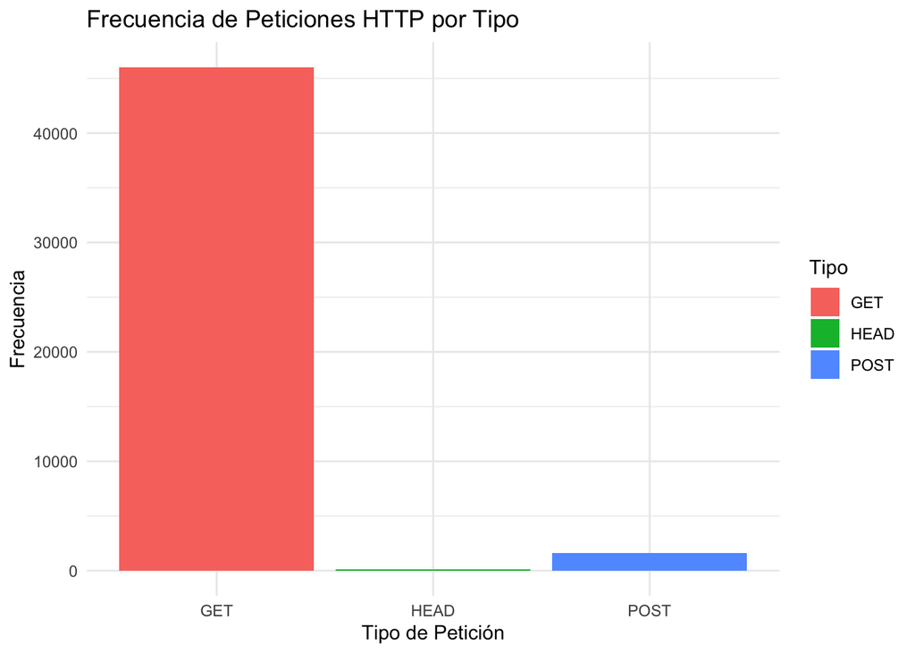

```r
library(ggplot2)

# Contamos la frecuencia de cada tipo de petición HTTP
frecuencia_peticiones <- as.data.frame(table(logs_df$Type))
colnames(frecuencia_peticiones) <- c("Tipo", "Frecuencia")

# Generamos el gráfico de frecuencia de peticiones HTTP por tipo
grafico_peticiones <- ggplot(data=frecuencia_peticiones, aes(x=Tipo, y=Frecuencia, fill=Tipo)) +
  geom_bar(stat="identity") +
  labs(title="Frecuencia de Peticiones HTTP por Tipo", x="Tipo de Petición", y="Frecuencia") +
  theme_minimal()

# Mostramos el gráfico
print(grafico_peticiones)
```

En segundo lugar, podemos ver que casi todas las imágenes descargadas son tipo GIF.

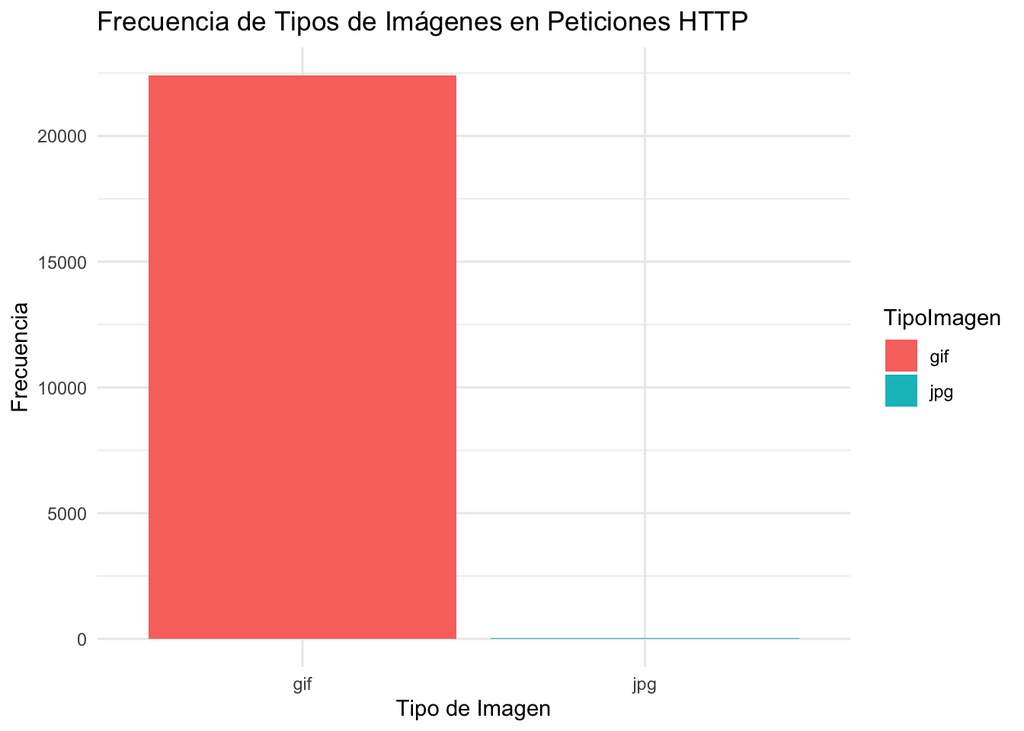

```r
grafico_imagenes <- ggplot(frecuencia_imagenes_df, aes(x = TipoImagen, y = Frecuencia, fill=TipoImagen)) +
  geom_bar(stat = "identity",) +
  theme_minimal() +
  labs(title = "Frecuencia de Tipos de Imágenes en Peticiones HTTP",
       x = "Tipo de Imagen",
       y = "Frecuencia")

# Mostramos el gráfico
print(grafico_imagenes)
```

En tercer lugar, la mayoría de mensajes de repuesta han sido exitosos.

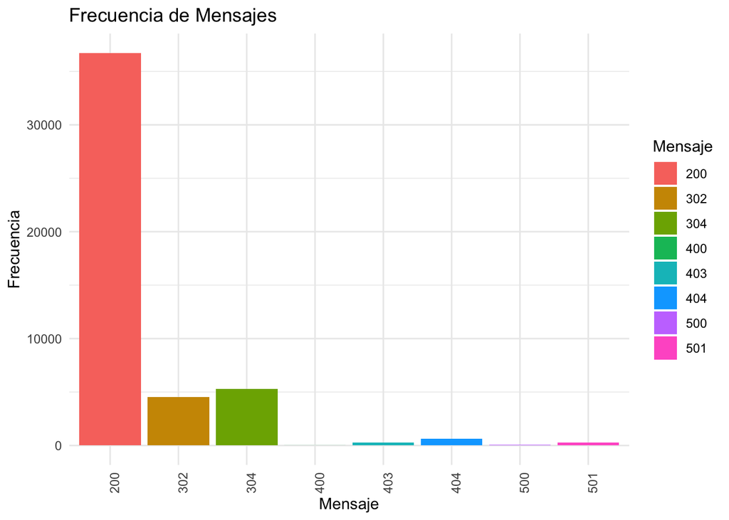

```r
# Contamos la frecuencia de cada mensaje
frecuencia_mensajes <- as.data.frame(table(logs_df$Mensaje))
colnames(frecuencia_mensajes) <- c("Mensaje", "Frecuencia")

# Generamos el gráfico de frecuencia de mensajes
grafico_mensajes <- ggplot(data=frecuencia_mensajes, aes(x=Mensaje, y=Frecuencia, fill=Mensaje)) +
  geom_bar(stat="identity") +
  labs(title="Frecuencia de Mensajes", x="Mensaje", y="Frecuencia") +
  theme_minimal() +
  theme(axis.text.x = element_text(angle = 90, hjust = 1))

# Mostramos el gráfico
print(grafico_mensajes)
```

### 7. Generar un gráfico que permita visualizar el número de peticiones servidas a lo largo del tiempo.

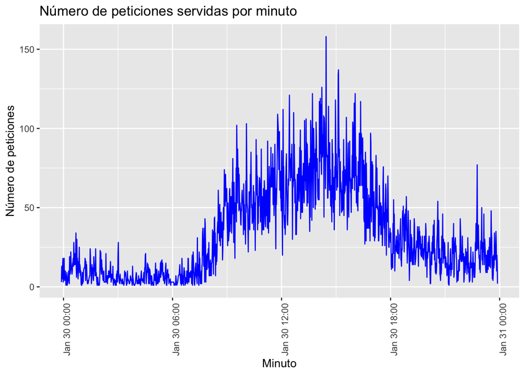

```r
# Convertimos la columna FechaHora al formato adecuado
logs_df$FechaHora <- as.POSIXct(logs_df$FechaHora, format="[%d:%H:%M:%S]")

# Extraemos el día y la hora de la columna FechaHora
logs_df$Dia <- as.Date(logs_df$FechaHora)
logs_df$Minuto <- format(logs_df$FechaHora, "%Y-%m-%d %H:%M")

# Contamos el número de peticiones por minuto
peticiones_por_minuto <- as.data.frame(table(logs_df$Minuto))
colnames(peticiones_por_minuto) <- c("Minuto", "Frecuencia")

# Generamos el gráfico de peticiones por minuto
grafico_minuto <- ggplot(data=peticiones_por_minuto, aes(x=as.POSIXct(Minuto, format="%Y-%m-%d %H:%M"), y=Frecuencia)) +
  geom_line(color="blue") +
  labs(title="Número de peticiones servidas por minuto", x="Minuto", y="Número de peticiones") +
  theme(axis.text.x = element_text(angle = 90, hjust = 1))

# Mostramos el gráfico
print(grafico_minuto)
```

# Clústering de datos

### 8. Utilizando un algoritmo de aprendizaje no supervisado, realizad un análisis de clústering con k-means para los datos del servidor.

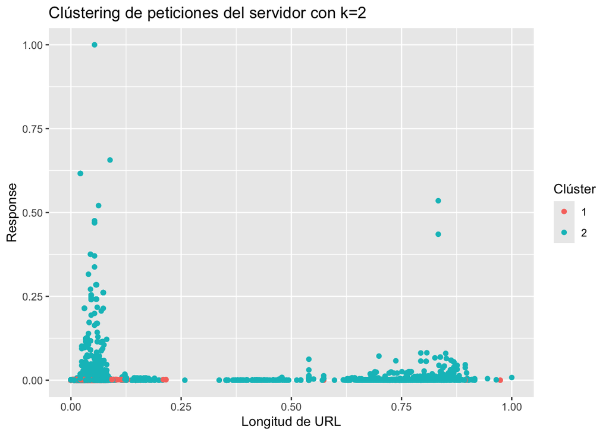

```r
# Librerías necesarias
library(mltools)
library(data.table)
library(scales)
library(ggplot2)

# Convertimos las columnas de tipo carácter a factores y aplicamos one-hot encoding
epa_http_one_hot <- one_hot(as.data.table(logs_df), sparsifyNAs = TRUE)

# Generamos una columna numérica con el número de caracteres de la URL
epa_http_one_hot$URL_length <- nchar(logs_df$URL)

# Imputamos valores NA en la columna Response con 0 bytes servidos si el código de respuesta es 404
epa_http_one_hot$Response[is.na(epa_http_one_hot$Response) & logs_df$Response == 404] <- 0

# Normalizamos los datos
epa_http_normalized <- as.data.frame(lapply(epa_http_one_hot, function(x) if(is.numeric(x)) rescale(x) else x))

# Reemplazamos NA, NaN e Inf con la media de la columna
epa_http_normalized <- as.data.frame(lapply(epa_http_normalized, function(x) if(is.numeric(x)) {
  x[is.na(x) | is.nan(x) | is.infinite(x)] <- mean(x, na.rm = TRUE)
  return(x)
} else x))

# Descartamos todas las columnas que no sean numéricas
epa_http_numeric <- epa_http_normalized[sapply(epa_http_normalized, is.numeric)]

# Aplicamos k-means con k=2, k=3, k=4 y k=5
set.seed(123) # Para reproducibilidad
kmeans_result_k2 <- kmeans(epa_http_numeric, centers = 2, nstart = 25)
epa_http_numeric$cluster_k2 <- kmeans_result_k2$cluster

kmeans_result_k3 <- kmeans(epa_http_numeric, centers = 3, nstart = 25)
epa_http_numeric$cluster_k3 <- kmeans_result_k3$cluster

kmeans_result_k4 <- kmeans(epa_http_numeric, centers = 4, nstart = 25)
epa_http_numeric$cluster_k4 <- kmeans_result_k4$cluster

kmeans_result_k5 <- kmeans(epa_http_numeric, centers = 5, nstart = 25)
epa_http_numeric$cluster_k5 <- kmeans_result_k5$cluster

# Gráficos de dispersión para k=2, k=3, k=4 y k=5
plot_k2 <- ggplot(epa_http_numeric, aes(x = URL_length, y = Response, color = factor(cluster_k2))) +
  geom_point() +
  labs(title = "Clústering de peticiones del servidor con k=2", x = "Longitud de URL", y = "Response", color = "Clúster")

plot_k3 <- ggplot(epa_http_numeric, aes(x = URL_length, y = Response, color = factor(cluster_k3))) +
  geom_point() +
  labs(title = "Clústering de peticiones del servidor con k=3", x = "Longitud de URL", y = "Response", color = "Clúster")

plot_k4 <- ggplot(epa_http_numeric, aes(x = URL_length, y = Response, color = factor(cluster_k4))) +
  geom_point() +
  labs(title = "Clústering de peticiones del servidor con k=4", x = "Longitud de URL", y = "Response", color = "Clúster")

plot_k5 <- ggplot(epa_http_numeric, aes(x = URL_length, y = Response, color = factor(cluster_k5))) +
  geom_point() +
  labs(title = "Clústering de peticiones del servidor con k=5", x = "Longitud de URL", y = "Response", color = "Clúster")

# Mostramos los gráficos
print(plot_k2)
```

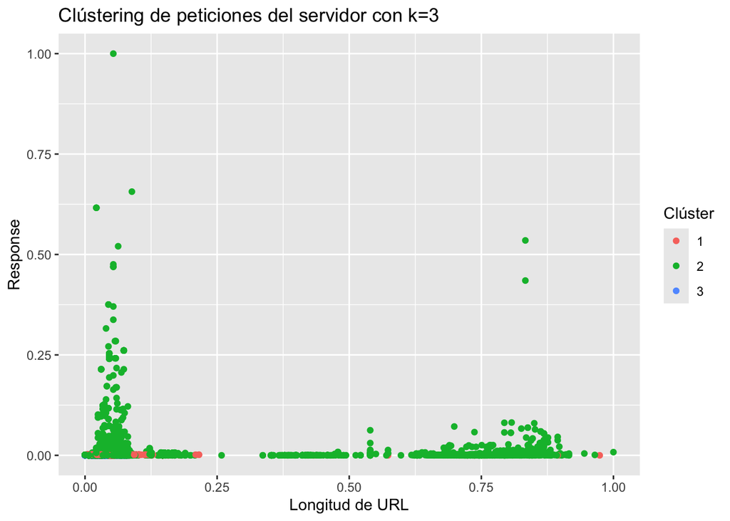

```r
print(plot_k3)
```

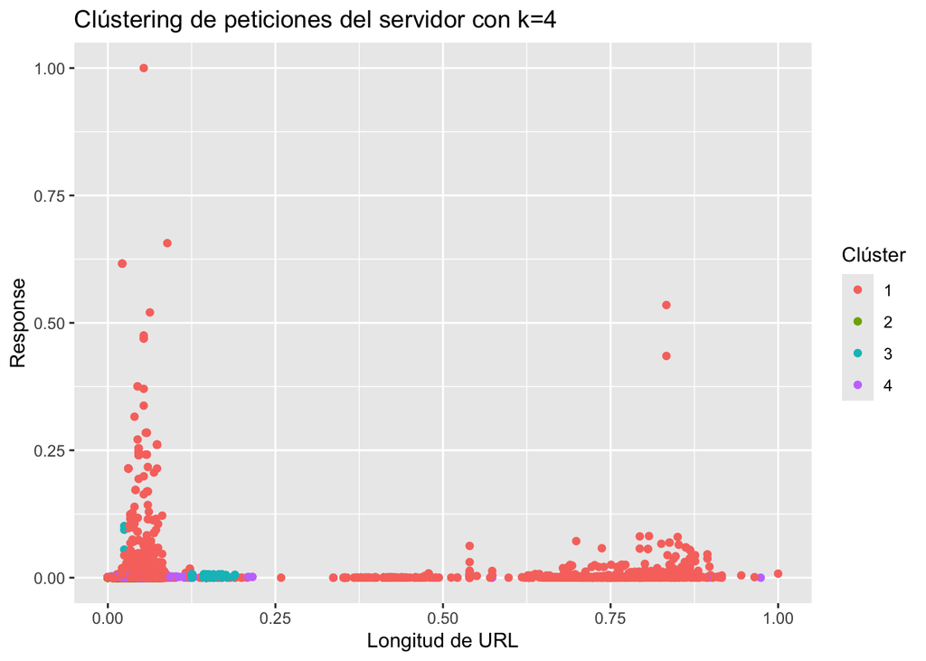

```r
print(plot_k4)
```

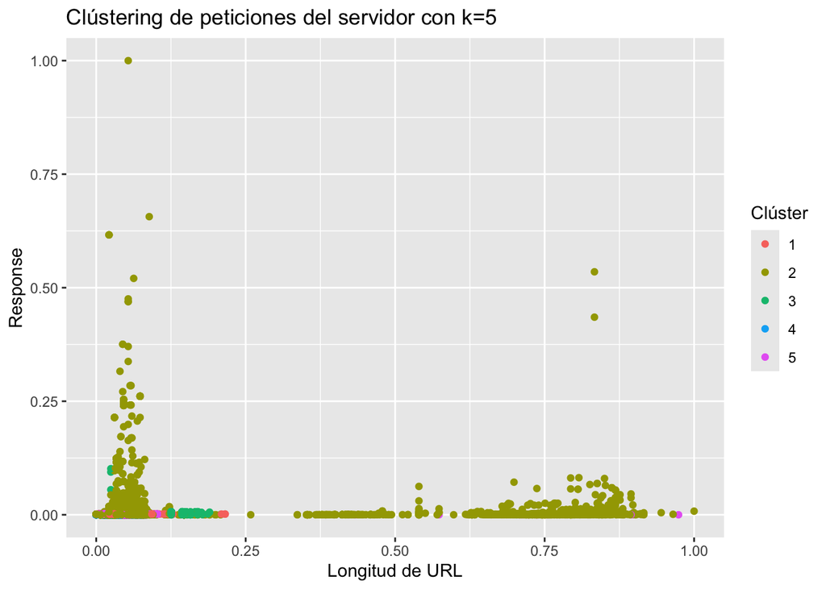

```r
print(plot_k5)
```

```r
library(tidyr)
library(dplyr)
```

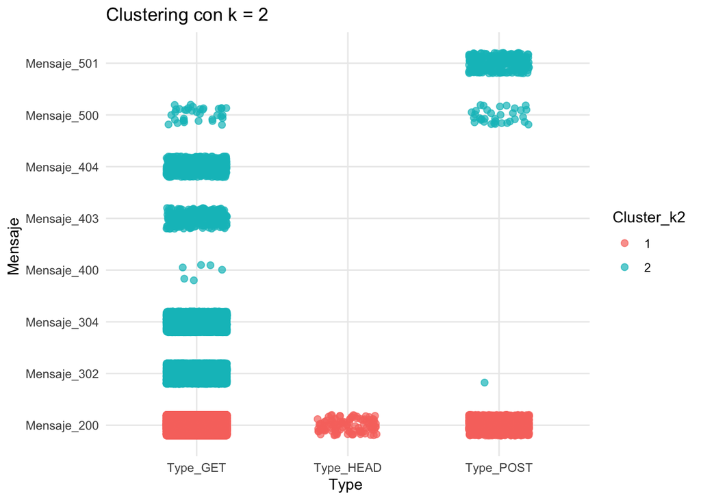

```r
library(ggplot2)

# Seleccionamos de las columnas de interés
variables_clustering <- epa_http_numeric[, c("Type_GET", "Type_HEAD", "Type_POST", "Mensaje_200", "Mensaje_302", "Mensaje_304", "Mensaje_400", "Mensaje_403", "Mensaje_404", "Mensaje_500", "Mensaje_501")]

# Aplicamos k-means para k = 2, 3, 4
set.seed(123)  # Para reproducibilidad

k2 <- kmeans(variables_clustering, centers = 2, nstart = 25)
k3 <- kmeans(variables_clustering, centers = 3, nstart = 25)
k4 <- kmeans(variables_clustering, centers = 4, nstart = 25)

# Agregamos los resultados de clústeres al dataframe original
epa_http_numeric$Cluster_k2 <- as.factor(k2$cluster)
epa_http_numeric$Cluster_k3 <- as.factor(k3$cluster)
epa_http_numeric$Cluster_k4 <- as.factor(k4$cluster)

# Reestructuramos los datos para que cada fila tenga un solo valor de Type y Mensaje
long_data <- variables_clustering %>%
  mutate(Cluster_k2 = epa_http_numeric$Cluster_k2,
         Cluster_k3 = epa_http_numeric$Cluster_k3,
         Cluster_k4 = epa_http_numeric$Cluster_k4) %>%
  pivot_longer(cols = c("Type_GET", "Type_HEAD", "Type_POST"),
               names_to = "Type",
               values_to = "Type_Value") %>%
  pivot_longer(cols = starts_with("Mensaje"),
               names_to = "Mensaje",
               values_to = "Mensaje_Value") %>%
  filter(Type_Value == 1 & Mensaje_Value == 1)

# Creamos una función para graficar los clústeres
plot_clusters <- function(data, cluster_col, title) {
  ggplot(data, aes(x = Type, y = Mensaje, color = !!sym(cluster_col))) +
    geom_jitter(width = 0.2, height = 0.2, alpha = 0.7, size = 2) +
    labs(title = title, x = "Type ", y = "Mensaje ") +
    theme_minimal()
}


# Graficamos los clústeres para k = 2, 3, 4
p1 <- plot_clusters(long_data, "Cluster_k2", "Clustering con k = 2")
p2 <- plot_clusters(long_data, "Cluster_k3", "Clustering con k = 3")
p3 <- plot_clusters(long_data, "Cluster_k4", "Clustering con k = 4")

# Mostramos gráficos
print(p1)
```

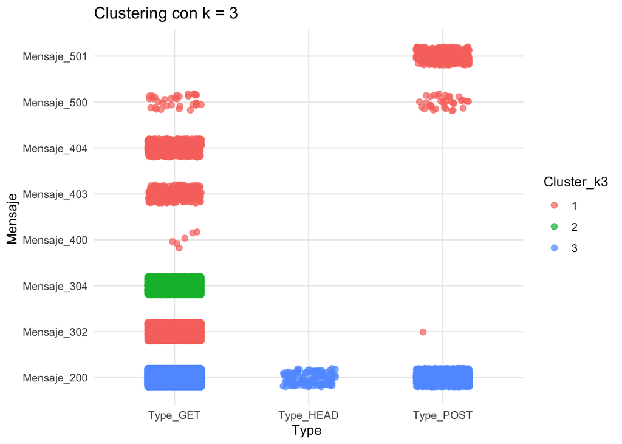

```r
print(p2)
```

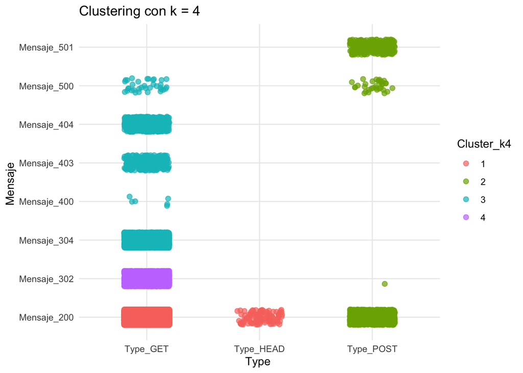

```r
print(p3)
```